# SimpsonsParadox

Dr. B

Friday, January 30, 2015

## Simpson Paradox

In probability and statistics, Simpson’s paradox (Yule-Simpson effect) is an apparent paradox in which a trend present in different groups is reversed when the groups are combined. Simpson’s Paradox is caused by a combination of a lurking variable and data from unequal sized groups being combined into a single data set. The unequal group sizes, in the presence of a lurking variable, can weight the results incorrectly. This can lead to seriously flawed conclusions. The obvious way to prevent it is to not combine data sets of different sizes from a diverse sources.

This result is often encountered in social-science and medical-science statistics. Simpson’s Paradox disappears when causal relations are brought into consideration.

### Load Data and Create a Table

#### Males

Nonsmokers without the disease: 36

Nonsmokers with the disease: 4

Smokers without the disease: 131

Smokers with the disease: 29

#### Females

Nonsmokers without the disease: 140

Nonsmokers with the disease: 60

Smokers without the disease: 27

Smokers with the disease: 23

### Raw results

```
##
##           Exposure
## Outcome    Non-exposed Exposed Total
##   Negative 176         158     334
##   Positive 64          52      116
##   Total    240         210     450
##
##            Rne         Re      Rt
##   Risk     0.27        0.25    0.26
##                                          Estimate Lower95ci Upper95ci
##  Risk difference (Re - Rne)              -0.02    -0.1      0.06
##  Risk ratio                              0.93     0.62      1.39
##  Protective efficacy =(Rne-Re)/Rne*100   7.1      -39.17    37.85
##    or percent of risk reduced
##  Number needed to treat (NNT)            52.5     -16.33    9.98
##    or -1/(risk difference)
```

Interpret the estimate risk difference: 2% fewer people in the smoker group got the disease (as compared to the non smoking group).

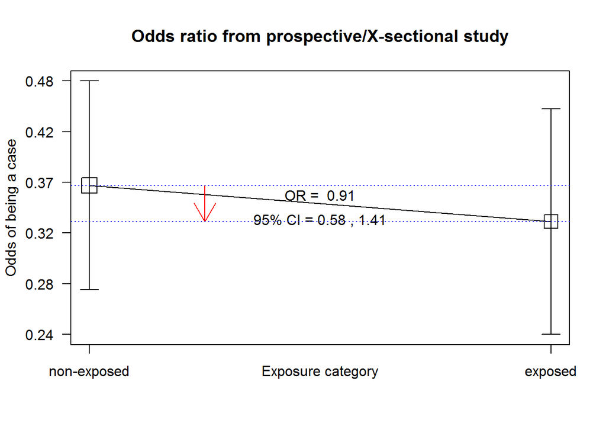

```
##
##           Exposure
## Outcome    Non-exposed Exposed Total
##   Negative         176     158   334
##   Positive          64      52   116
##   Total            240     210   450
##
## OR =  0.91
## Exact 95% CI =  0.58, 1.41
## Chi-squared = 0.21, 1 d.f., P value = 0.645
## Fisher's exact test (2-sided) P value = 0.667
```

### Results for males only:

```
##
##           Exposure
## Outcome    Non-exposed Exposed Total
##   Negative 36          131     167
##   Positive 4           29      33
##   Total    40          160     200
##
##            Rne         Re      Rt
##   Risk     0.1         0.18    0.16
##
##                                          Estimate Lower95ci Upper95ci
##  Risk difference (attributable risk)     0.08     -0.02     0.23
##  Risk ratio                              1.81     0.57      5.79
##  Attr. frac. exp. -- (Re-Rne)/Re         0.45
##  Attr. frac. pop. -- (Rt-Rne)/Rt*100 %   39.39
##  Number needed to harm (NNH)             12.31    -40.91    4.32
##    or 1/(risk difference)
```

Interpret the estimate risk difference: 8% more males in the smoker group got the disease (as compared to the non smoking group).

```
##
##           Exposure
## Outcome    Non-exposed Exposed Total
##   Negative          36     131   167
##   Positive           4      29    33
##   Total             40     160   200
##
## OR =  1.99
## Exact 95% CI =  0.64, 8.28
## Chi-squared = 1.53, 1 d.f., P value = 0.216
## Fisher's exact test (2-sided) P value = 0.339
```

### Results for only the females

```
##
##           Exposure
## Outcome    Non-exposed Exposed Total
##   Negative 140         27      167
##   Positive 60          23      83
##   Total    200         50      250
##
##            Rne         Re      Rt
##   Risk     0.3         0.46    0.33
##
##                                          Estimate Lower95ci Upper95ci
##  Risk difference (attributable risk)     0.16     0.01      0.29
##  Risk ratio                              1.53     1         2.33
##  Attr. frac. exp. -- (Re-Rne)/Re         0.35
##  Attr. frac. pop. -- (Rt-Rne)/Rt*100 %   9.64
##  Number needed to harm (NNH)             6.25     3.46      148.21
##    or 1/(risk difference)
```

Interpret the estimate risk difference: 16% more females in the smoker group got the disease (as compared to the non smoking group).

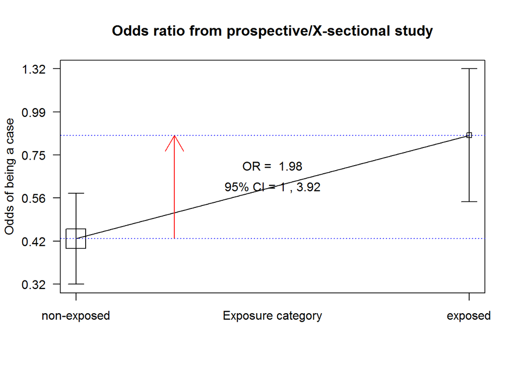

```
##
##           Exposure
## Outcome    Non-exposed Exposed Total
##   Negative         140      27   167
##   Positive          60      23    83
##   Total            200      50   250
##
## OR =  1.99
## Exact 95% CI =  1, 3.92
## Chi-squared = 4.62, 1 d.f., P value = 0.032
## Fisher's exact test (2-sided) P value = 0.043
```

(This is an R Markdown document. Markdown is a simple formatting syntax for authoring HTML, PDF, and MS Word documents. For more details on using R Markdown see http://rmarkdown.rstudio.com.)